# Final Project Report - Musician Wages Analysis

Gregory Glatzer

5/4/2021

# Introduction

Growing up I was surrounded by music. My father played piano nearly every day, and my sister the clarinet. In 4th grade, I picked up the clarinet and joined the school band. Since then, I have been in countless bands, orchestras, and jazz bands, playing clarinet, saxophone, and flute. When I started this project, I was excited to find a dataset created by the [New Music Organizing Caucus](https://www.newmusicorganizingcaucus.org/), which gathers information about gigs of musicians. I then compare this dataset to information gathered from the [Bureau of Labor Statistics](https://datausa.io/profile/soc/musicians-and-singers) on musicians and singers. This allows me to validate the data gathered from the Caucus, and analyze the distribution of musicians across the country, as well as the nature of the gigs they are getting.

# Research Question

How does the distribution of professional musicians and their wage vary across the United States?

# Setup

```r
library(tidyverse)
```

[output not shown]

```r
library(ggplot2)
library(usmap)
rm(list = ls())
```

# The Data

```r
# Dataset from the New Music Organzing Caucus
# https://www.newmusicorganizingcaucus.org/real-music-wages-database.html
Wages <- readr::read_csv("Music Wage DB.csv")

# Dataset from the Bureau of Labor Statistics
# https://datausa.io/profile/soc/musicians-and-singers
BLS <- readr::read_csv("bls_gov_metrowise.csv")
```

Let’s look at the data we are working with.

## The Bureau of Labor Statistics Dataset

[figure not shown]

The first dataset is from the Bureau of Labor Statistics. It contains information gathered by the government agency regarding concentrations and wages of musicians throughout the United States. More specifically, this dataset is split up into information in different “PUMAs”. A PUMA is a “Public Use Microdata Area” within the United States and territories as defined by the US Census Bureau. The dataset provides musician and singer population statistics for each area.

```r
# Data for the Bureau of Labor Statistics
BLS %>% head()
```

| Area Name | Employment(1) | Employment percent relative standard error(3) | Hourly mean wage | Annual mean wage(2) | Wage percent relative standard error(3) | Hourly 10th percentile wage | Hourly 25th percentile wage | Hourly median wage | Hourly 75th percentile wage | Hourly 90th percentile wage | Annual 10th percentile wage(2) | Annual 25th percentile wage(2) | Annual median wage(2) | Annual 75th percentile wage(2) | Annual 90th percentile wage(2) | Employment per 1,000 jobs | Location Quotient |
| --- | --- | --- | --- | --- | --- | --- | --- | --- | --- | --- | --- | --- | --- | --- | --- | --- | --- |
| Akron, OH(0010420) | 30 | 34.2 | - | - | - | - | - | - | - | - | - | - | - | - | - | 0.109 | 0.44 |
| Albany, OR(0010540) | 70 | 29.4 | 16.47 | - | 17.5 | 11.23 | 11.24 | 11.24 | 12.22 | 37.28 | - | - | - | - | - | 1.562 | 6.25 |
| Albany-Schenectady-Troy, NY(0010580) | 60 | 41.7 | - | - | - | - | - | - | - | - | - | - | - | - | - | 0.149 | 0.6 |
| Ann Arbor, MI(0011460) | - | - | 37.08 | - | 17.4 | 13.45 | 15.57 | 39.56 | 48.56 | 62.38 | - | - | - | - | - | - | - |
| Appleton, WI(0011540) | 70 | 10 | 11.38 | - | 7.8 | 7.58 | 7.95 | 8.58 | 9.21 | 22.28 | - | - | - | - | - | 0.584 | 2.34 |
| Arizona nonmetropolitan area(0400001) | - | - | 13.4 | - | 5.9 | 12.1 | 12.53 | 13.41 | 14.29 | 14.81 | - | - | - | - | - | - | - |

```r
BLS %>% glimpse()
```

```
Rows: 122
Columns: 18
$ `Area Name`                                     <chr> "Akr...
$ `Employment(1)`                                 <chr> "30"...
$ `Employment percent relative standard error(3)` <chr> "34....
$ `Hourly mean wage`                              <chr> "-",...
$ `Annual mean wage(2)`                           <chr> "-",...
$ `Wage percent relative standard error(3)`       <chr> "-",...
$ `Hourly 10th percentile wage`                   <chr> "-",...
$ `Hourly 25th percentile wage`                   <chr> "-",...
$ `Hourly median wage`                            <chr> "-",...
$ `Hourly 75th percentile wage`                   <chr> "-",...
$ `Hourly 90th percentile wage`                   <chr> "-",...
$ `Annual 10th percentile wage(2)`                <chr> "-",...
$ `Annual 25th percentile wage(2)`                <chr> "-",...
$ `Annual median wage(2)`                         <chr> "-",...
$ `Annual 75th percentile wage(2)`                <chr> "-",...
$ `Annual 90th percentile wage(2)`                <chr> "-",...
$ `Employment per 1,000 jobs`                     <chr> "0.1...
$ `Location Quotient`                             <chr> "0.4...
```

## The New Music Organizing Caucus Dataset

[figure not shown]

The second dataset I will be looking at is from the New Music Organizing Caucus, who at the end of 2019 released a form for musicians to fill out information about the gigs they have been doing, including where, when, and how much they were paid for each gig. Unfortunately, many gigs stopped in March of 2020, which probably hindered the dataset from growing. Regardless, this dataset has 100+ rows of information regarding musician gigs and wages.

```r
# Data from the New Music Organizing Caucus
Wages %>% head()
```

| timestamp | whopaid | howmuch | howlong | where | tags | tour? | union? |
| --- | --- | --- | --- | --- | --- | --- | --- |
| 11/24/2020 16:42 | Alarm Will Sound | 1017.5 | 7.5 | St. Louis, MO, USA | the grandel, small ensemble, new music | NA | NA |
| 11/24/2020 16:42 | Alarm Will Sound | 850 | 8 | Hanover, NH, USA | dartmouth university, shift festival, small ensemble, new music | NA | NA |
| 1/9/2021 11:42 | Alarm Will Sound | 1900 | 43 | St. Louis, MO, USA | small ensemble, new music | NA | NA |
| 1/26/2021 18:10 | American Composers Association | 175 | 8 | New York, NY, USA | solo,home recording,new music | NA | NA |
| 1/26/2021 18:10 | American Composers Association | 150 | 1 | New York, NY, USA | home recording,new music,solo | NA | NA |
| 1/18/2021 19:55 | American Composers Orchestra | 150 | 3.5 | New York, NY, USA | orchestra, new music, composer reading | NA | NA |

```r
Wages %>% glimpse()
```

```
Rows: 121
Columns: 8
$ timestamp <chr> "11/24/2020 16:42", "11/24/2020 16:42", "1...
$ whopaid   <chr> "Alarm Will Sound", "Alarm Will Sound", "A...
$ howmuch   <chr> "1017.5", "850", "1900", "175", "150", "15...
$ howlong   <chr> "7.5", "8", "43", "8", "1", "3.5", "486", ...
$ where     <chr> "St. Louis, MO, USA", "Hanover, NH, USA", ...
$ tags      <chr> "the grandel, small ensemble, new music", ...
$ `tour?`   <chr> NA, NA, NA, NA, NA, NA, NA, NA, NA, NA, "y...
$ `union?`  <lgl> NA, NA, NA, NA, NA, NA, NA, NA, NA, NA, NA...
```

Even before answering our research question, we will need to wrangle the data into a more usable form. In both datasets, all of the columns are characters. One of the first steps of data wrangling will be to cast the columns to their intrinsic data types. Also, the state abbreviations, which will be used to plot geogrpahic data, are currently not in their own columns, but rather inside the `where` and `Area Name` columns. Both these problems will be addressed in the next section.

## Data wrangling

First, let’s do some type casting to make the data easy to work with, and so various graphs act as we expect them to. For example, casting the string “4” to the numeric value 4.

```r
BLS <- BLS %>%
  na_if("-") %>% # Empty values are dashes (-) in this dataset
  type_convert() # Easy way to typecast lots of columns for you in one go
Wages <- Wages %>%
  mutate( # some manual typecasting as needed here, as type_convert() doesn't work as expected sometimes
    whopaid = as.factor(whopaid),
    howmuch = as.numeric(howmuch),
    howlong = as.numeric(howlong),
    )
```

```
NAs introduced by coercionNAs introduced by coercion
```

In order to do geographic analysis, we will need the state of each row. This piece of information is not by itself in its own column. This needs to be done before we can make any kind of maps. Let’s extract the state from the `Area Name` column in **BLS**, and the `where` column in **Wages**.

```r
# Extract state in BLS
BLS <- BLS %>%
  rename(areaName = "Area Name") %>%
  extract(areaName, c("PUMA"), "\\((.*)\\)", remove = FALSE) %>% # extract PUMA Code into own column from location
  extract(areaName, c("areaName"), "(.*)\\(") %>%
  mutate(state = str_extract(areaName, "(?<=, )([A-Z]{2})")) # identify State with regex expression
BLS %>% distinct(state)
```

| state |
| --- |
| OH |
| OR |
| NY |
| MI |
| WI |
| NA |
| GA |
| TX |
| MD |
| MT |

[output cut: 29 more lines]

```r
# Extract state in Wages
Wages <- Wages %>%
  mutate(state = str_extract(where, "(?<=, )([A-Z]{2})"))
Wages %>% distinct(state)
```

| state |
| --- |
| MO |
| NH |
| NY |
| CA |
| TX |
| MA |
| OR |
| IL |
| MI |
| NJ |

[output cut: 8 more lines]

Let’s take one last look at the data, to make sure it is ready to go for analysis.

```r
BLS %>% head()
```

| areaName | PUMA | Employment(1) | Employment percent relative standard error(3) | Hourly mean wage | Annual mean wage(2) | Wage percent relative standard error(3) | Hourly 10th percentile wage | Hourly 25th percentile wage | Hourly median wage | Hourly 75th percentile wage | Hourly 90th percentile wage | Annual 10th percentile wage(2) | Annual 25th percentile wage(2) | Annual median wage(2) | Annual 75th percentile wage(2) | Annual 90th percentile wage(2) | Employment per 1,000 jobs | Location Quotient | state |
| --- | --- | --- | --- | --- | --- | --- | --- | --- | --- | --- | --- | --- | --- | --- | --- | --- | --- | --- | --- |
| Akron, OH | 0010420 | 30 | 34.2 | NA | NA | NA | NA | NA | NA | NA | NA | NA | NA | NA | NA | NA | 0.109 | 0.44 | OH |
| Albany, OR | 0010540 | 70 | 29.4 | 16.47 | NA | 17.5 | 11.23 | 11.24 | 11.24 | 12.22 | 37.28 | NA | NA | NA | NA | NA | 1.562 | 6.25 | OR |
| Albany-Schenectady-Troy, NY | 0010580 | 60 | 41.7 | NA | NA | NA | NA | NA | NA | NA | NA | NA | NA | NA | NA | NA | 0.149 | 0.60 | NY |
| Ann Arbor, MI | 0011460 | NA | NA | 37.08 | NA | 17.4 | 13.45 | 15.57 | 39.56 | 48.56 | 62.38 | NA | NA | NA | NA | NA | NA | NA | MI |
| Appleton, WI | 0011540 | 70 | 10.0 | 11.38 | NA | 7.8 | 7.58 | 7.95 | 8.58 | 9.21 | 22.28 | NA | NA | NA | NA | NA | 0.584 | 2.34 | WI |
| Arizona nonmetropolitan area | 0400001 | NA | NA | 13.40 | NA | 5.9 | 12.10 | 12.53 | 13.41 | 14.29 | 14.81 | NA | NA | NA | NA | NA | NA | NA | NA |

```r
Wages %>% head()
```

| timestamp | whopaid | howmuch | howlong | where | tags | tour? | union? | state |
| --- | --- | --- | --- | --- | --- | --- | --- | --- |
| 11/24/2020 16:42 | Alarm Will Sound | 1017.5 | 7.5 | St. Louis, MO, USA | the grandel, small ensemble, new music | NA | NA | MO |
| 11/24/2020 16:42 | Alarm Will Sound | 850.0 | 8.0 | Hanover, NH, USA | dartmouth university, shift festival, small ensemble, new music | NA | NA | NH |
| 1/9/2021 11:42 | Alarm Will Sound | 1900.0 | 43.0 | St. Louis, MO, USA | small ensemble, new music | NA | NA | MO |
| 1/26/2021 18:10 | American Composers Association | 175.0 | 8.0 | New York, NY, USA | solo,home recording,new music | NA | NA | NY |
| 1/26/2021 18:10 | American Composers Association | 150.0 | 1.0 | New York, NY, USA | home recording,new music,solo | NA | NA | NY |
| 1/18/2021 19:55 | American Composers Orchestra | 150.0 | 3.5 | New York, NY, USA | orchestra, new music, composer reading | NA | NA | NY |

# Discussion

## Location Quotient (Musician density)

In order to answer our research question, we need a statistic that describes the concentration of musicians and singers in each area/state. Luckily for us, within the BLS dataset, there is a feature called the “Location Quotient”. The BLS defines location quotient as:

> “Location quotients compare the concentration of an industry within a specific area to the concentration of that industry nationwide”

> — https://www.bls.gov/cew/about-data/location-quotients-explained.htm

By analyzing the distribution of location quotient, we can get a good understanding of where there a high concentration of musicians throughout the country.

Let’s consider the distribution of this feature.

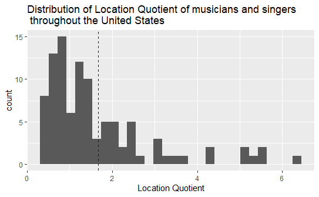

```r
avgLocQuot <- mean(BLS$`Location Quotient`, na.rm = TRUE)

BLS %>%
  ggplot(aes(x = `Location Quotient`)) +
  geom_histogram(aes(x = `Location Quotient`)) +
  geom_vline(aes(xintercept = avgLocQuot), linetype = "dashed", color = "blue") +
  labs(title = "Distribution of Location Quotient of musicians and singers\n throughout the United States")
```

The distribution is skewed right with an average of 1.67. *(It makes sense that the average is a little above 1, since the data is skewed right, and that the data collection is not perfect.)* Let’s look at the outliers, as they would be areas with especially high concentration of musicians and singers. A common practice for classifying outliers is any value more than the 3rd quartile + 1.5 x IQR can be considered an outlier.

```r
BLS$`Location Quotient` %>% summary()
```

```
   Min. 1st Qu.  Median    Mean 3rd Qu.    Max.    NA's
  0.310   0.810   1.280   1.669   2.040   6.250      23
```

```r
# calculate IQR
IQR <- 2.040 - 0.810
upper_cutoff <- 2.040 + (IQR * 1.5)
LocQuoOutliers <- BLS %>%
  filter(`Location Quotient` > upper_cutoff)

LocQuoOutliers %>%
  select(areaName, "Location Quotient")
```

| areaName | Location Quotient |
| --- | --- |
| Albany, OR | 6.25 |
| Eugene, OR | 5.62 |
| Great Falls, MT | 5.22 |
| Hawaii / Kauai nonmetropolitan area | 5.36 |
| Kahului-Wailuku-Lahaina, HI | 5.57 |
| Missoula, MT | 4.26 |
| Nashville-Davidson--Murfreesboro--Franklin, TN | 5.09 |
| Urban Honolulu, HI | 4.20 |

Let’s look at Location Quotient in a map view. We can plot the location quotient on a map using the usmap package.

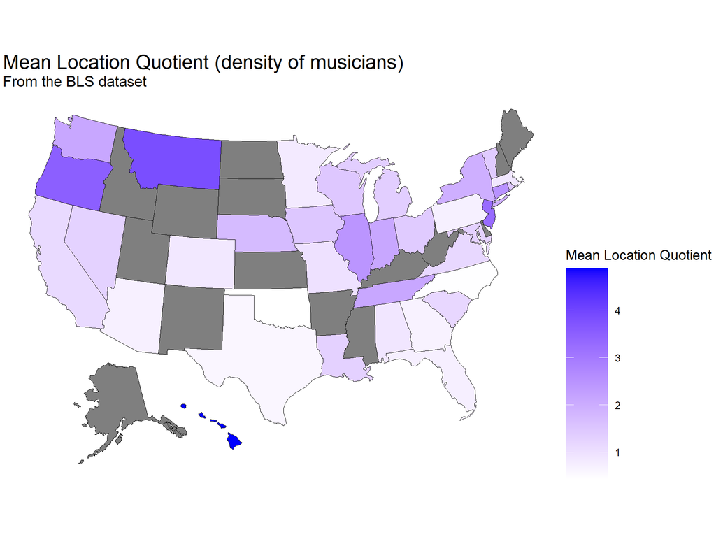

```r
MeanLocQuots <- BLS %>%
  group_by(state) %>%
  summarize(meanLocQuot = mean(`Location Quotient`, na.rm = TRUE)) %>%
  select(state, meanLocQuot) %>%
  drop_na(state, meanLocQuot)

makeMap <- function(data, key, title, subtitle, legendTitle) {
  plot_usmap(data = data, values = key, color = "black", regions = "states") +
  scale_fill_continuous(low = "white", high = "blue", name = legendTitle) +
  theme(
  legend.position = "right",
  legend.title = element_text(color = "black", size = 28),
  legend.text = element_text(color = "black", size = 20),
  legend.key.size = unit(3, "cm"),
  plot.title = element_text(size = 40),
  plot.subtitle = element_text(size = 30)
  ) +
  labs(title = title, subtitle = subtitle)
}

makeMap(MeanLocQuots,
        "meanLocQuot",
        "Mean Location Quotient (density of musicians)",
        "From the BLS dataset",
        "Mean Location Quotient"
        )
```

Here we see the outliers again as very dark. However, you also start to see trends of more musicians in northeastern United States and midwest, and less in the lower half of the country.

It is interesting when you compare Location Quotient to hourly mean wage, which has a fairly normal, bell-shaped distribution:

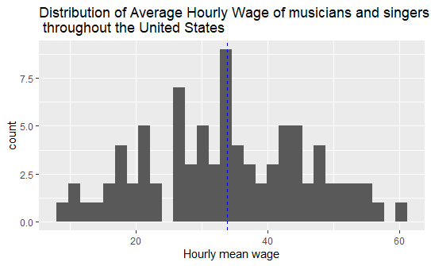

```r
avgHourlyWage <- mean(BLS$`Hourly mean wage`, na.rm = TRUE)

BLS %>%
  ggplot(aes(x = `Hourly mean wage`)) +
  geom_histogram(aes(x = `Hourly mean wage`)) +
  geom_vline(aes(xintercept = avgHourlyWage), linetype = "dashed", color="blue") +
  labs(title = "Distribution of Average Hourly Wage of musicians and singers\n throughout the United States")
```

Although there are some areas with high concentration of musicians, there are not extreme outliers of wage to match these concentrations.

In order to investigate this further, I want to make a jitter plot of the hourly mean wage, and highlight these outliers to see where they fall.

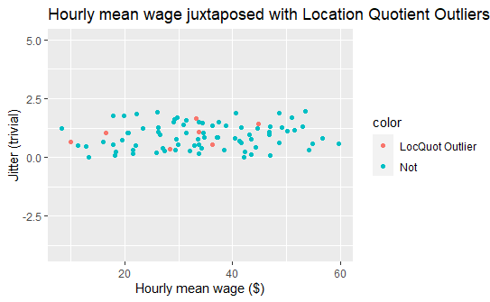

```r
jitter <- position_jitter(width = 0, height = 1)

BLS$color <- ifelse(BLS$areaName %in% LocQuoOutliers$areaName, "LocQuot Outlier", "Not")

BLS %>%
  ggplot() +
  geom_point(
    position = jitter,
    aes(x = `Hourly mean wage`, y = 1, color = color)) +
  labs(title = "Hourly mean wage juxtaposed with Location Quotient Outliers") +
  ylim(-4, 5) +
  ylab("Jitter (trivial)") +
  xlab("Hourly mean wage ($)")
```

Interestingly, these outliers are not in any particular range of wages, so it doesn’t seem that Location Quotient has a strong correlation with Hourly Mean Wage. In other words, areas with lots of musicians does not necessarily mean that there is a higher wage. Another way to look at this is the regression line between the 2 variables.

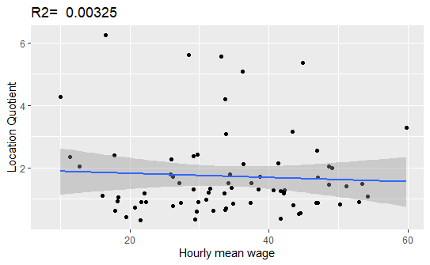

```r
m <- lm(`Location Quotient` ~ `Hourly mean wage`, data = BLS)

BLS %>%
  ggplot(aes(x = `Hourly mean wage`, y = `Location Quotient`)) +
  geom_point() +
  stat_smooth(data = BLS, aes(x = `Hourly mean wage`, y = `Location Quotient`), method = "lm") +
  labs(title = paste("R2= ", signif(summary(m)$r.squared, digits = 3)))
```

```r
NA
```

We can see that the regression line is fairly flat, which would mean change in Hourly Mean Wage doesn’t have much effect, if at all, on the density of musicians in an area.

## Hourly mean wage

Let’s plot Hourly mean wage on a map. This is the same process we used for Location Quotient.

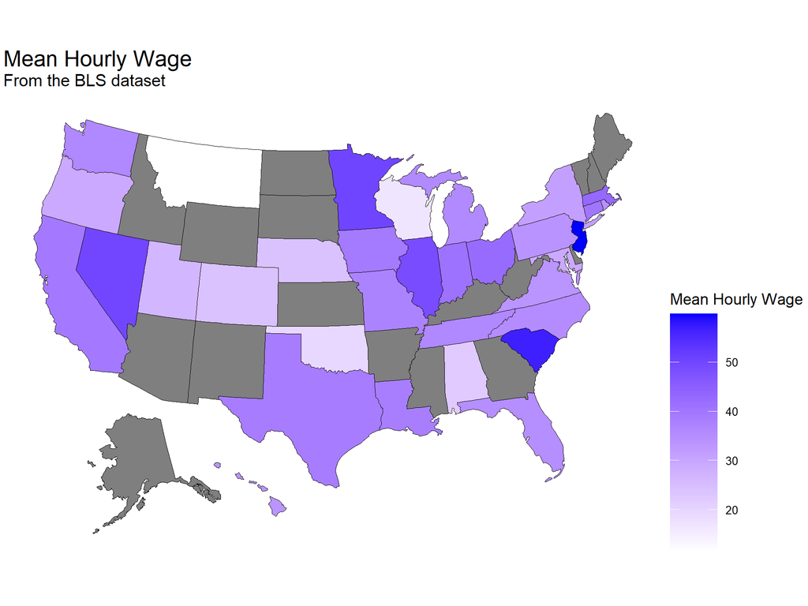

```r
MeanWages <- BLS %>%
  group_by(state) %>%
  summarize(meanHourlyWage = mean(`Hourly mean wage`, na.rm = TRUE)) %>%
  select(state, meanHourlyWage) %>%
  drop_na(state, meanHourlyWage)

makeMap(
  MeanWages,
  "meanHourlyWage",
  "Mean Hourly Wage",
  "From the BLS dataset",
  "Mean Hourly Wage"
)
```

The major trends I notice are there being darker (higher wage) states in the Midwest, and lighter states in the West. Along the coasts there does not tend to be any major trends, with outliers such as NJ and South Carolina.

## Analyzing the second dataset

The second dataset holds some interesting information regarding music gigs. In particular, what organization paid for the gigs, and how long they were. Let’s take a look at the length of the gigs, first.

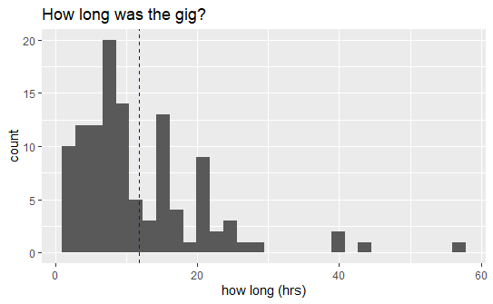

```r
Wages %>%
  filter(howlong < 100) %>%
  ggplot(aes(x = howlong)) +
  geom_histogram() +
  geom_vline(aes(xintercept = mean(howlong)), linetype = "dashed", color="blue") +
  labs(title = "How long was the gig?") +
  xlab(("how long (hrs)"))
```

The average length gig is around 12 hours. It is important to note that this dataset defines how long as rehearsal time + performance. So the “longer” gigs most likely had more rehearsal time (and they probably got paid for that, too).

A good variable to compare this to to get an idea of how length of gigs affects pay would be `howmuch`. Let’s plot these two against each other.

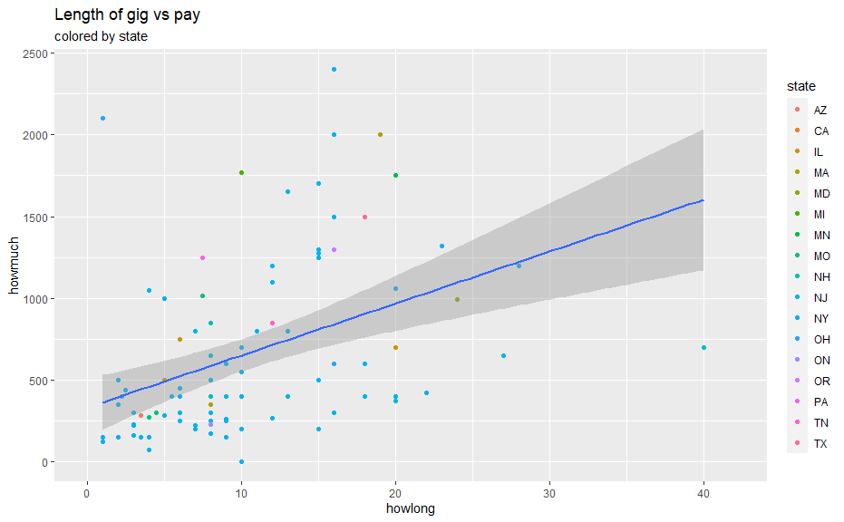

```r
Wages %>%
  filter(howlong < 100) %>%
  drop_na(state) %>%
  ggplot(aes(x = howlong, y = howmuch)) +
  geom_point(aes(color = state)) +
  stat_smooth(method = "lm") +
  xlim(0, 42) +
  labs(title = "Length of gig vs pay", subtitle = "colored by state")
```

As expected, gigs that are longer pay better.

The next feature of this dataset I want to investigate is `whopaid`. This will give me an idea of the big employers in different states, which is good to know for my research question of wage distribution.

```r
Wages %>%
  drop_na(state) %>%
  count(whopaid, whopaid) %>%
  arrange(desc(n))
```

| whopaid | n |
| --- | --- |
| Talea Ensemble | 6 |
| Ensemble Signal | 4 |
| Hotel Elefant | 4 |
| Alarm Will Sound | 3 |
| Contemporaneous | 3 |
| Wordless Music Orchestra | 3 |
| American Composers Association | 2 |
| American Composers Orchestra | 2 |
| Columbia University | 2 |
| Elan Artists | 2 |

[output cut: 67 more lines]

Looking through the list, most of the gigs come from orchestras or chamber orchestras. Some big names are in there, including the New York Phil, American Composers Association, and Berklee. Also, some fun expects exist, such as the Tonight Show. One major caveat of this dataset is that the vast majority of the data is from the NY / NJ area. Because of this, the data is not a good representation of the country, as groups such as the LA Phil, Chicago Symphony, Philadelphia Orchestra, and Philadelphia Chamber Music Society are not represented, to name a few. Regardless, I believe this list still gives a good insight into who is paying musicians. It is mostly orchestras, chamber music groups, and some institutions.

Finally, we can join this to the BLS dataset, to see who the paying organizations are in the states with the top wages.

```r
WagesAndWho <- Wages %>%
  left_join(BLS, by = c("state" = "state")) %>%
  drop_na(state, whopaid) %>%
  arrange(desc(`Hourly mean wage`)) %>%
  select(`Hourly mean wage`, state, whopaid)

MaxWhos <- WagesAndWho %>%
  count(state, whopaid) %>%
  group_by(state) %>%
  filter(n == max(n))

WagesAndWho %>%
  right_join(MaxWhos) %>%
  drop_na(`Hourly mean wage`) %>%
  group_by(state) %>%
  filter(row_number() == 1) %>%
  arrange(desc(`Hourly mean wage`)) %>%
  head(5)
```

| Hourly mean wage | state | whopaid | n |
| --- | --- | --- | --- |
| 59.78 | NJ | Elan Artists | 2 |
| 54.28 | CA | Art of Elan | 12 |
| 51.10 | OH | Johnstone Fund | 14 |
| 50.24 | MN | Quince Ensemble | 1 |
| 48.70 | IL | Dal Niente | 2 |

```r
NA
```

These are the top organizations (how many gigs they funded) in the 5 states with the highest hourly mean wage!

# Conclusion